# Assignment 3

Analyze a dataset of climate-related tweets collected from different countries.  
Dataset: `Climate_Tweets_Sample.csv`

```python
import numpy as np
import pandas as pd
import matplotlib.pyplot as plt
import seaborn as sns
import sklearn
```

## Part A – Cleaning & Sentiment Overview

### Dataset

```python
df = pd.read_csv('https://raw.githubusercontent.com/TheChroniclerr/CP321/refs/heads/main/a3/assets/Climate_Tweets_Sample.csv')
df.head()
```

|  | tweet_id | date | country | sentiment | keyword | text | retweet_count | like_count |
| --- | --- | --- | --- | --- | --- | --- | --- | --- |
| 0 | 2803826677020224 | 2023-11-01 | Denmark | negative | air quality | Breaking: concerns grow over air quality; data... | 80.0 | 92.0 |
| 1 | 1119349365897942 | 2022-11-16 | Spain | negative | air quality | Reminder: concerns grow over air quality; deta... | 14.0 | 125.0 |
| 2 | 3605591970800719 | 2023-01-20 | France | neutral | green transition | FYI: discussion continues on green transition;... | 78.0 | 109.0 |
| 3 | 4546715437012377 | 2023-09-10 | Saudi Arabia | negative | green transition | Opinion: concerns grow over green transition; ... | 75.0 | 63.0 |
| 4 | 9630049315224554 | 2022-09-26 | Ireland | negative | global warming | Opinion: global warming impacts are worsening;... | 58.0 | 58.0 |

### Clean

Missing values in `retweet_count` and `like_count` were replaced using the median value of each column. The median is less sensitive to outliers than the mean and provides a reasonable estimate of central tendency for social media engagement data.

```python
# Duplicate detection
print(df.duplicated().sum())
print('----------')

# Find missing values
print(df.isna().sum())
```

```
0
----------
tweet_id          0
date              0
country           0
sentiment         0
keyword           0
text              0
retweet_count    38
like_count       32
dtype: int64
```

```python
# Proper date parsing
df['date'] = pd.to_datetime(df['date'], errors='coerce')

# Duplicate handling
df = df.drop_duplicates()

# Handling missing values in columns with proper justification
df['retweet_count'] = df['retweet_count'].fillna(df['retweet_count'].median())
df['like_count'] = df['like_count'].fillna(df['like_count'].median())

# Display result
df.info()
df
```

```
<class 'pandas.core.frame.DataFrame'>
RangeIndex: 2000 entries, 0 to 1999
Data columns (total 8 columns):
 #   Column         Non-Null Count  Dtype
---  ------         --------------  -----
 0   tweet_id       2000 non-null   int64
 1   date           2000 non-null   datetime64[ns]
 2   country        2000 non-null   object
 3   sentiment      2000 non-null   object
 4   keyword        2000 non-null   object
 5   text           2000 non-null   object
 6   retweet_count  2000 non-null   float64
 7   like_count     2000 non-null   float64
dtypes: datetime64[ns](1), float64(2), int64(1), object(4)
memory usage: 125.1+ KB
```

|  | tweet_id | date | country | sentiment | keyword | text | retweet_count | like_count |
| --- | --- | --- | --- | --- | --- | --- | --- | --- |
| 0 | 2803826677020224 | 2023-11-01 | Denmark | negative | air quality | Breaking: concerns grow over air quality; data... | 80.0 | 92.0 |
| 1 | 1119349365897942 | 2022-11-16 | Spain | negative | air quality | Reminder: concerns grow over air quality; deta... | 14.0 | 125.0 |
| 2 | 3605591970800719 | 2023-01-20 | France | neutral | green transition | FYI: discussion continues on green transition;... | 78.0 | 109.0 |
| 3 | 4546715437012377 | 2023-09-10 | Saudi Arabia | negative | green transition | Opinion: concerns grow over green transition; ... | 75.0 | 63.0 |
| 4 | 9630049315224554 | 2022-09-26 | Ireland | negative | global warming | Opinion: global warming impacts are worsening;... | 58.0 | 58.0 |
| ... | ... | ... | ... | ... | ... | ... | ... | ... |
| 1995 | 6114707426537667 | 2021-07-14 | India | negative | carbon tax | FYI: alarm raised about carbon tax; what do yo... | 48.0 | 110.0 |
| 1996 | 6518489934791567 | 2021-07-04 | China | negative | fossil fuels | Update: concerns grow over fossil fuels; stay ... | 23.0 | 147.0 |
| 1997 | 2244138508075894 | 2023-11-29 | Australia | positive | green transition | Reminder: encouraging signs for green transiti... | 69.0 | 127.0 |
| 1998 | 4958684821663573 | 2022-04-19 | Indonesia | negative | sustainability | Report: alarm raised about sustainability; det... | 3.0 | 65.0 |
| 1999 | 2250898629368768 | 2021-08-10 | Germany | negative | heatwave | Report: alarm raised about heatwave; check the... | 48.0 | 122.0 |

2000 rows × 8 columns

```python
# Lock a cleaned copy for export
df_cleaned = df.copy()
```

### Sentiment Visualization

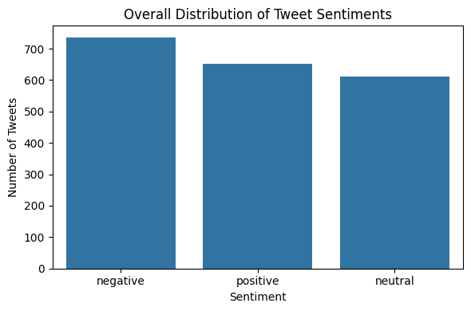

```python
plt.figure(figsize=(6,4))

sns.countplot(
    data=df,
    x='sentiment',
    order=df['sentiment'].value_counts().index
)

plt.title("Overall Distribution of Tweet Sentiments")
plt.xlabel("Sentiment")
plt.ylabel("Number of Tweets")

plt.tight_layout()
plt.show()
```

[figure not shown]

```python
top_countries = df['country'].value_counts().head(10).index

plt.figure(figsize=(10,6))

sns.countplot(
    data=df[df['country'].isin(top_countries)],
    y='country',
    hue='sentiment',
    order=top_countries
)

plt.title("Sentiment Distribution Across Top 10 Countries")
plt.xlabel("Country")
plt.ylabel("Number of Tweets")
plt.legend(title="Sentiment")

plt.tight_layout()
plt.show()
```

## Part B – Text Preprocess & Word Cloud

```python
# Text preprocessing
import re
import nltk
from nltk.corpus import stopwords

# Keyword & word cloud analysis
from collections import Counter
from wordcloud import WordCloud
```

### Text Preprocessing

```python
nltk.download('stopwords')
stop_words = set(stopwords.words('english'))

def clean_text(text):
    text = text.lower()                     # lowercase
    text = re.sub(r'[^a-z\s]', '', text)    # remove punctuation and numbers
    words = [word for word in text.split() if word not in stop_words]   # remove stopwords

    return " ".join(words)

df['cleaned_text'] = df['text'].apply(clean_text)
df
```

|  | tweet_id | date | country | sentiment | keyword | text | retweet_count | like_count | cleaned_text |
| --- | --- | --- | --- | --- | --- | --- | --- | --- | --- |
| 0 | 2803826677020224 | 2023-11-01 | Denmark | negative | air quality | Breaking: concerns grow over air quality; data... | 80.0 | 92.0 | breaking concerns grow air quality data attached |
| 1 | 1119349365897942 | 2022-11-16 | Spain | negative | air quality | Reminder: concerns grow over air quality; deta... | 14.0 | 125.0 | reminder concerns grow air quality details inc... |
| 2 | 3605591970800719 | 2023-01-20 | France | neutral | green transition | FYI: discussion continues on green transition;... | 78.0 | 109.0 | fyi discussion continues green transition chec... |
| 3 | 4546715437012377 | 2023-09-10 | Saudi Arabia | negative | green transition | Opinion: concerns grow over green transition; ... | 75.0 | 63.0 | opinion concerns grow green transition check f... |
| 4 | 9630049315224554 | 2022-09-26 | Ireland | negative | global warming | Opinion: global warming impacts are worsening;... | 58.0 | 58.0 | opinion global warming impacts worsening stay ... |
| ... | ... | ... | ... | ... | ... | ... | ... | ... | ... |
| 1995 | 6114707426537667 | 2021-07-14 | India | negative | carbon tax | FYI: alarm raised about carbon tax; what do yo... | 48.0 | 110.0 | fyi alarm raised carbon tax think |
| 1996 | 6518489934791567 | 2021-07-04 | China | negative | fossil fuels | Update: concerns grow over fossil fuels; stay ... | 23.0 | 147.0 | update concerns grow fossil fuels stay informed |
| 1997 | 2244138508075894 | 2023-11-29 | Australia | positive | green transition | Reminder: encouraging signs for green transiti... | 69.0 | 127.0 | reminder encouraging signs green transition st... |
| 1998 | 4958684821663573 | 2022-04-19 | Indonesia | negative | sustainability | Report: alarm raised about sustainability; det... | 3.0 | 65.0 | report alarm raised sustainability details inc... |
| 1999 | 2250898629368768 | 2021-08-10 | Germany | negative | heatwave | Report: alarm raised about heatwave; check the... | 48.0 | 122.0 | report alarm raised heatwave check figures |

2000 rows × 9 columns

### Keyword & Word Cloud Analysis

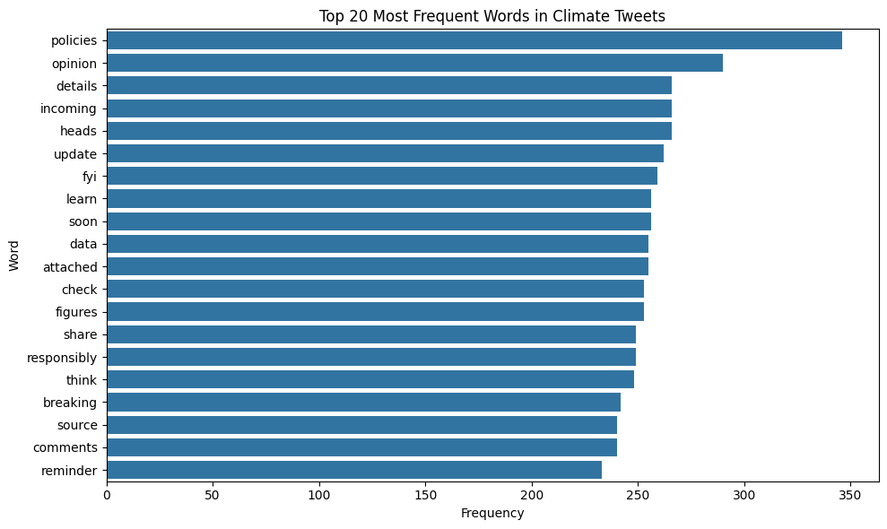

```python
all_words = " ".join(df['cleaned_text']).split()    # Tokenize words
top20 = Counter(all_words).most_common(20)          # Count frequency
freq_df = pd.DataFrame(top20, columns=['word', 'count'])    # to DataFrame

plt.figure(figsize=(10,6))

sns.barplot(
    data=freq_df,
    x='count',
    y='word'
)

plt.title("Top 20 Most Frequent Words in Climate Tweets")
plt.xlabel("Frequency")
plt.ylabel("Word")

plt.tight_layout()
plt.show()
```

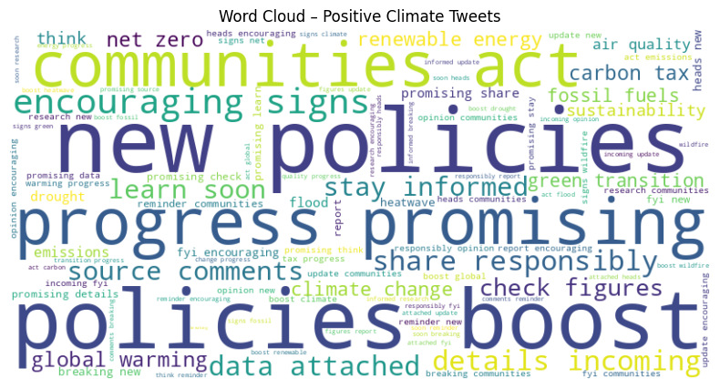

```python
positive_text = " ".join(df[df["sentiment"] == "positive"]["cleaned_text"])

wordcloud_pos = WordCloud(
    width=800,
    height=400,
    background_color="white"
).generate(positive_text)

plt.figure(figsize=(10,5))
plt.imshow(wordcloud_pos, interpolation="bilinear")
plt.axis("off")

plt.title("Word Cloud – Positive Climate Tweets")

plt.show()
```

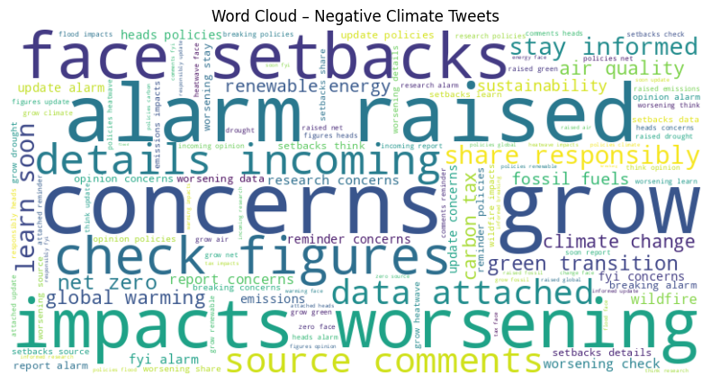

```python
negative_text = " ".join(df[df["sentiment"] == "negative"]["cleaned_text"])

wordcloud_neg = WordCloud(
    width=800,
    height=400,
    background_color="white"
).generate(negative_text)

plt.figure(figsize=(10,5))
plt.imshow(wordcloud_neg, interpolation="bilinear")
plt.axis("off")

plt.title("Word Cloud – Negative Climate Tweets")

plt.show()
```

## Part C – Geospatial Visualization

```python
!pip install --upgrade plotly
!pip install pycountry kaleido

import pycountry
import plotly.express as px
from IPython.core.display import display, HTML
```

```python
# Convert to ISO-3 country codes (stop deprecation warning)
country_fix = {     # manual name fix
    "Russia": "Russian Federation",
    "Turkey": "Türkiye"
}

def get_iso3(country_name):
    try:
        name_fixed = country_fix.get(country_name, country_name)
        return pycountry.countries.lookup(name_fixed).alpha_3
    except LookupError:
        return None

df['iso_country'] = df['country'].apply(get_iso3)

# Check for failed conversions
df[df['iso_country'].isna()]['country'].unique()
```

```
array([], dtype=object)
```

```python
country_counts = df.groupby('iso_country').size().reset_index(name="tweet_count")

fig = px.choropleth(
    country_counts,
    locations="iso_country",        # column with country names
    locationmode="ISO-3",
    color="tweet_count",        # metric to visualize
    hover_name="iso_country",
    color_continuous_scale="YlOrRd",  # Yellow → Orange → Red
)

fig.update_layout(
    title_text="Number of Climate Tweets by Country",
    geo=dict(showframe=False, showcoastlines=True),
)

fig.show()  # html data, does not render on notebook

# fig.write_html("climate_tweets_map.html")
# with open("climate_tweets_map.html", "r") as f:
#     html_content = f.read()
# display(HTML(html_content))
```

[interactive chart not shown]

## Part D – Uncertainty & Association

### Monthly Negative Sentiment Rate + 95% confidence interval (CI).

To compute the monthly negative sentiment rate, I divided the number of negative tweets by the total tweets each month and calculated 95% confidence intervals using the Wilson method, which is suitable for proportions and accounts for uncertainty in months with fewer tweets. The plot shows that negative sentiment fluctuates over time, with some months exhibiting higher public concern about climate issues. The shaded CI highlights uncertainty, indicating when the rate estimates are less precise due to smaller sample sizes.

```python
from statsmodels.stats.proportion import proportion_confint
```

```python
# Process dataset
df['month'] = df['date'].dt.to_period('M')
monthly_counts = df.groupby('month')['sentiment'].value_counts().unstack(fill_value=0)
monthly_counts['total'] = monthly_counts.sum(axis=1)
monthly_counts['neg_rate'] = monthly_counts.get('negative', 0) / monthly_counts['total']

# Compute 95% CI using Wilson method
confint = monthly_counts.apply(
    lambda row: proportion_confint(
        count=row.get('negative', 0),
        nobs=row['total'],
        alpha=0.05,
        method='wilson'
    ), axis=1
)

monthly_counts['ci_lower'] = [c[0] for c in confint]
monthly_counts['ci_upper'] = [c[1] for c in confint]

monthly_counts.head()
```

| sentiment month | negative | neutral | positive | total | neg_rate | ci_lower | ci_upper |
| --- | --- | --- | --- | --- | --- | --- | --- |
| 2021-01 | 8 | 15 | 17 | 40 | 0.200000 | 0.105000 | 0.347573 |
| 2021-02 | 18 | 17 | 11 | 46 | 0.391304 | 0.263932 | 0.535432 |
| 2021-03 | 19 | 21 | 22 | 62 | 0.306452 | 0.205816 | 0.429672 |
| 2021-04 | 14 | 16 | 15 | 45 | 0.311111 | 0.195287 | 0.456648 |
| 2021-05 | 16 | 18 | 24 | 58 | 0.275862 | 0.177524 | 0.402047 |

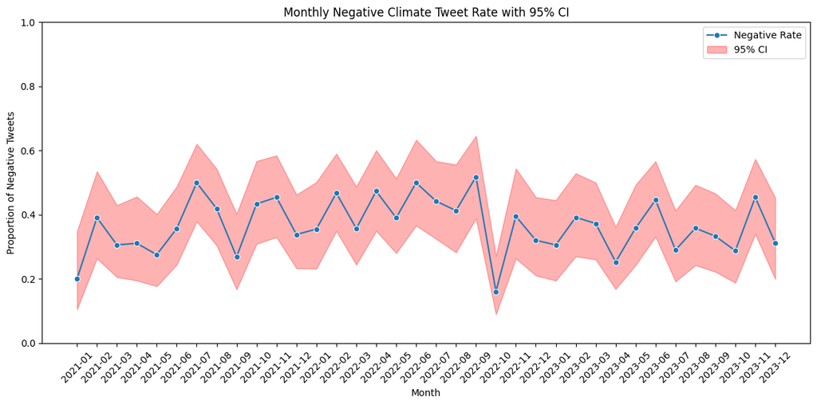

```python
plt.figure(figsize=(12,6))

sns.lineplot(
    x=monthly_counts.index.astype(str),
    y=monthly_counts['neg_rate'],
    marker='o',
    label='Negative Rate'
)

plt.fill_between(
    monthly_counts.index.astype(str),
    monthly_counts['ci_lower'],
    monthly_counts['ci_upper'],
    alpha=0.3, color='red', label='95% CI'
)

plt.title("Monthly Negative Climate Tweet Rate with 95% CI")
plt.xlabel("Month")
plt.ylabel("Proportion of Negative Tweets")
plt.xticks(rotation=45)
plt.legend()
plt.ylim(0, 1)

plt.tight_layout()
plt.show()
```

### Scatter/Bubble: Likes vs Retweets

I plotted likes versus retweets for the top 5 countries to avoid overcrowding and used color to represent sentiment and bubble size to indicate retweet magnitude. The scatter plot shows a positive correlation between likes and retweets, with some negative tweets receiving particularly high engagement. This visualization helps identify which types of tweets attract attention and allows comparison of engagement patterns across sentiments and countries.

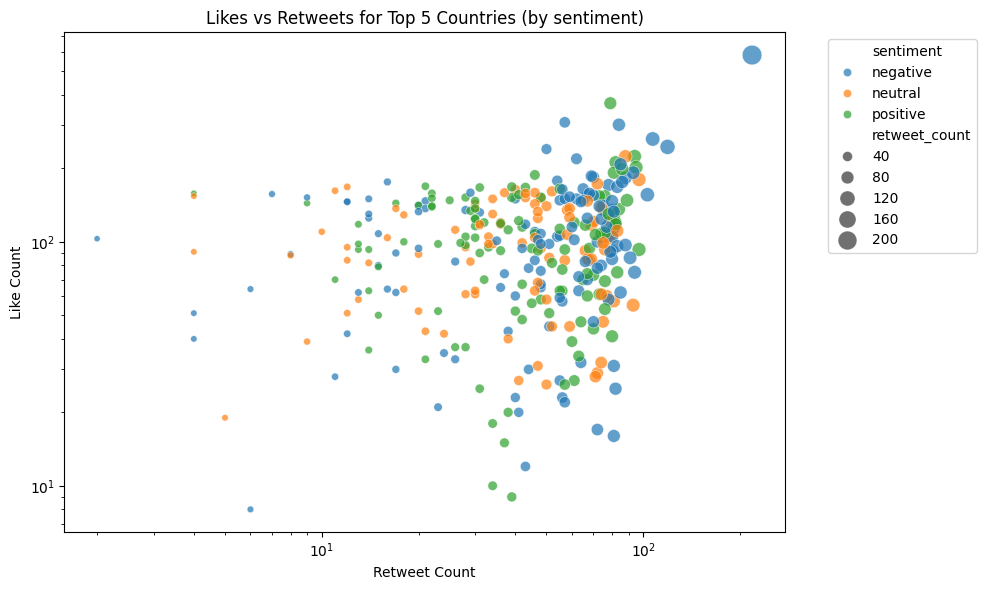

```python
top_countries = df['country'].value_counts().head(5).index
df_top = df[df['country'].isin(top_countries)]

plt.figure(figsize=(10,6))

sns.scatterplot(
    data=df_top,
    x='retweet_count',
    y='like_count',
    hue='sentiment',
    size='retweet_count',
    sizes=(20, 200),
    alpha=0.7
)

plt.title("Likes vs Retweets for Top 5 Countries (by sentiment)")
plt.xlabel("Retweet Count")
plt.ylabel("Like Count")
plt.xscale('log')
plt.yscale('log')
plt.legend(bbox_to_anchor=(1.05,1), loc='upper left')

plt.tight_layout()
plt.show()
```

## Part E – Design & Insight

**Insights:** The analysis shows that negative climate tweets are consistently present, but certain months experience spikes in public concern. Some countries dominate the conversation, particularly those with larger tweet counts, and the choropleth highlights geographic concentration of climate discourse. The scatter plot indicates that high-engagement tweets are not limited to positive or neutral sentiment; negative tweets often generate considerable interaction, suggesting that concern or alarm drives sharing. Word cloud and keyword analysis revealed recurring topics like air quality, carbon tax, and green transition, reflecting the issues that capture public attention. Overall, the visualizations collectively reveal temporal, geographic, and sentiment-driven patterns in climate-related discourse, offering both a quantitative and qualitative understanding of public engagement.

### Export

```python
# Export cleaned CSV
df_cleaned.to_csv("cleaned.csv", index=False)
```